# When Your Predictor Disappears: Mediation vs. Multiple Regression

Rahul Venugopal

2026-05-11

## The Puzzle

Bill length predicts body mass (r = 0.60). That’s clear and significant. But add flipper length to the model and the bill-length coefficient collapses — from **β = 0.595** to a non-significant **β = 0.041**. Did bill length suddenly stop mattering? No. Something subtler is happening: bill length’s effect on body mass is being **carried** by flipper length, not blocked by it.

This post walks through that story in two complementary ways — **multiple regression** to quantify the coefficient collapse, and **mediation analysis** to formally decompose *why* it happens.

## Setup

```r
library(palmerpenguins)
library(mediation)
library(tidyverse)
library(broom)
library(patchwork)
```

```r
# Drop rows with NAs in our three variables, then standardise
penguins_clean <- na.omit(penguins[, c("body_mass_g", "flipper_length_mm", "bill_length_mm")])
penguins_s     <- as.data.frame(scale(penguins_clean))
```

Standardising (z-scoring) means every coefficient below is in **standard-deviation units**, so comparisons across models are apples-to-apples.

## Figure 1 — All three variables are correlated

Before modelling anything, it is worth seeing the raw relationships. All three pairwise correlations are positive and substantial.

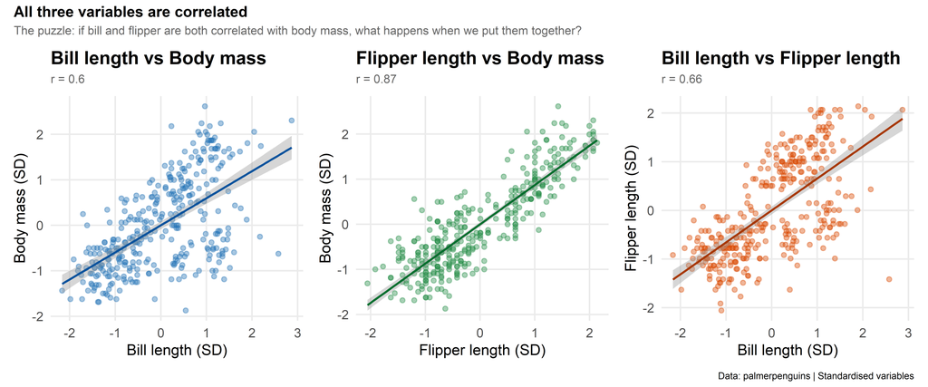

```r
theme_blog <- theme_minimal(base_size = 15) +
  theme(
    plot.title       = element_text(face = "bold", size = 17, margin = margin(b = 6)),
    plot.subtitle    = element_text(color = "grey40", size = 11, margin = margin(b = 10)),
    plot.caption     = element_text(color = "grey50", size = 9,  margin = margin(t = 10)),
    axis.title       = element_text(size = 14),
    panel.grid.minor = element_blank(),
    plot.background  = element_rect(fill = "white", color = NA)
  )

scatter_bm_bl <- ggplot(penguins_s, aes(x = bill_length_mm, y = body_mass_g)) +
  geom_point(alpha = 0.4, color = "#2171b5", size = 1.8) +
  geom_smooth(method = "lm", se = TRUE, color = "#08519c", linewidth = 0.9) +
  labs(x = "Bill length (SD)", y = "Body mass (SD)",
       title = "Bill length vs Body mass",
       subtitle = paste0("r = ", round(cor(penguins_s$bill_length_mm, penguins_s$body_mass_g), 2))) +
  theme_blog

scatter_fl_bm <- ggplot(penguins_s, aes(x = flipper_length_mm, y = body_mass_g)) +
  geom_point(alpha = 0.4, color = "#238b45", size = 1.8) +
  geom_smooth(method = "lm", se = TRUE, color = "#006d2c", linewidth = 0.9) +
  labs(x = "Flipper length (SD)", y = "Body mass (SD)",
       title = "Flipper length vs Body mass",
       subtitle = paste0("r = ", round(cor(penguins_s$flipper_length_mm, penguins_s$body_mass_g), 2))) +
  theme_blog

scatter_bl_fl <- ggplot(penguins_s, aes(x = bill_length_mm, y = flipper_length_mm)) +
  geom_point(alpha = 0.4, color = "#d94801", size = 1.8) +
  geom_smooth(method = "lm", se = TRUE, color = "#a63603", linewidth = 0.9) +
  labs(x = "Bill length (SD)", y = "Flipper length (SD)",
       title = "Bill length vs Flipper length",
       subtitle = paste0("r = ", round(cor(penguins_s$bill_length_mm, penguins_s$flipper_length_mm), 2))) +
  theme_blog

scatter_bm_bl + scatter_fl_bm + scatter_bl_fl +
  plot_annotation(
    title    = "All three variables are correlated",
    subtitle = "The puzzle: if bill and flipper are both correlated with body mass, what happens when we put them together?",
    caption  = "Data: palmerpenguins | Standardised variables",
    theme    = theme(
      plot.title      = element_text(face = "bold", size = 14),
      plot.subtitle   = element_text(color = "grey40", size = 11),
      plot.background = element_rect(fill = "white", color = NA)
    )
  )
```

The key tension: bill length (r = 0.60) and flipper length (r = 0.87) are both associated with body mass, *and* they are correlated with each other (r = 0.66). When correlated predictors compete in the same model, the coefficients can shift dramatically.